# Análisis de Factores que Predicen el Rendimiento Académico

Trabajo Final – Curso Analítica de Datos Industriales (ADI&TD)

José Alejandro Mora Poblete – Doctorado Interinstitucional en Ingeniería Industrial – Di3

2026-03-22

# 1 Introducción

El rendimiento académico de los estudiantes es un fenómeno complejo que depende de múltiples factores: hábitos de estudio, asistencia, motivación, contexto socioeconómico y condiciones del entorno escolar, entre otros. Comprender cuáles de estos factores tienen mayor influencia sobre el resultado final de un examen es una pregunta relevante tanto para instituciones educativas como para investigadores en ciencias del aprendizaje.

En el contexto de la Ingeniería Industrial, la analítica de datos aplicada a la educación puede considerarse análoga al análisis de procesos productivos: los estudiantes son el “sistema”, los factores son las “variables de entrada” y el puntaje del examen es la “variable de salida” o indicador de desempeño. Identificar qué variables impulsan o frenan ese desempeño permite diseñar intervenciones más efectivas.

El presente trabajo aplica un **modelo de regresión lineal múltiple** para predecir el puntaje obtenido en el examen final (`Exam_Score`) a partir de variables numéricas y categóricas disponibles en el dataset. Este método fue seleccionado por su interpretabilidad, simplicidad y coherencia con los contenidos abordados en el curso.

**Fuente del dataset:** Kaggle – *Student Exam Performance Dataset*  
https://www.kaggle.com/datasets/grandmaster07/student-exam-performance-dataset-analysis  
**Observaciones:** 6.607 estudiantes | **Variables:** 20

# 2 Librerías utilizadas

```r
library(ggplot2)
library(dplyr)
library(corrplot)
library(caret)
library(tidyr)
```

# 3 Carga y exploración inicial de datos

```r
# Cargar datos
datos <- read.csv("StudentPerformanceFactors.csv", stringsAsFactors = TRUE)

# Dimensiones y primeras filas
dim(datos)
```

```
## [1] 6607   20
```

```r
head(datos)
```

```
##   Hours_Studied Attendance Parental_Involvement Access_to_Resources
## 1            23         84                  Low                High
## 2            19         64                  Low              Medium
## 3            24         98               Medium              Medium
## 4            29         89                  Low              Medium
## 5            19         92               Medium              Medium
## 6            19         88               Medium              Medium
##   Extracurricular_Activities Sleep_Hours Previous_Scores Motivation_Level
## 1                         No           7              73              Low
## 2                         No           8              59              Low
## 3                        Yes           7              91           Medium
## 4                        Yes           8              98           Medium
## 5                        Yes           6              65           Medium
## 6                        Yes           8              89           Medium
##   Internet_Access Tutoring_Sessions Family_Income Teacher_Quality School_Type
```

[output cut: 20 more lines]

```r
# Estructura del dataset
str(datos)
```

```
## 'data.frame':    6607 obs. of  20 variables:
##  $ Hours_Studied             : int  23 19 24 29 19 19 29 25 17 23 ...
##  $ Attendance                : int  84 64 98 89 92 88 84 78 94 98 ...
##  $ Parental_Involvement      : Factor w/ 3 levels "High","Low","Medium": 2 2 3 2 3 3 3 2 3 3 ...
##  $ Access_to_Resources       : Factor w/ 3 levels "High","Low","Medium": 1 3 3 3 3 3 2 1 1 3 ...
##  $ Extracurricular_Activities: Factor w/ 2 levels "No","Yes": 1 1 2 2 2 2 2 2 1 2 ...
##  $ Sleep_Hours               : int  7 8 7 8 6 8 7 6 6 8 ...
##  $ Previous_Scores           : int  73 59 91 98 65 89 68 50 80 71 ...
##  $ Motivation_Level          : Factor w/ 3 levels "High","Low","Medium": 2 2 3 3 3 3 2 3 1 3 ...
##  $ Internet_Access           : Factor w/ 2 levels "No","Yes": 2 2 2 2 2 2 2 2 2 2 ...
##  $ Tutoring_Sessions         : int  0 2 2 1 3 3 1 1 0 0 ...
##  $ Family_Income             : Factor w/ 3 levels "High","Low","Medium": 2 3 3 3 3 3 2 1 3 1 ...
##  $ Teacher_Quality           : Factor w/ 4 levels "","High","Low",..: 4 4 4 4 2 4 4 2 3 2 ...
##  $ School_Type               : Factor w/ 2 levels "Private","Public": 2 2 2 2 2 2 1 2 1 2 ...
##  $ Peer_Influence            : Factor w/ 3 levels "Negative","Neutral",..: 3 1 2 1 2 3 2 1 2 3 ...
##  $ Physical_Activity         : int  3 4 4 4 4 3 2 2 1 5 ...
##  $ Learning_Disabilities     : Factor w/ 2 levels "No","Yes": 1 1 1 1 1 1 1 1 1 1 ...
##  $ Parental_Education_Level  : Factor w/ 4 levels "","College","High School",..: 3 2 4 3 2 4 3 3 2 3 ...
##  $ Distance_from_Home        : Factor w/ 4 levels "","Far","Moderate",..: 4 3 4 3 4 4 3 2 4 3 ...
##  $ Gender                    : Factor w/ 2 levels "Female","Male": 2 1 2 2 1 2 2 2 2 2 ...
##  $ Exam_Score                : int  67 61 74 71 70 71 67 66 69 72 ...
```

```r
# Estadísticas descriptivas
summary(datos)
```

```
##  Hours_Studied     Attendance     Parental_Involvement Access_to_Resources
##  Min.   : 1.00   Min.   : 60.00   High  :1908          High  :1975
##  1st Qu.:16.00   1st Qu.: 70.00   Low   :1337          Low   :1313
##  Median :20.00   Median : 80.00   Medium:3362          Medium:3319
##  Mean   :19.98   Mean   : 79.98
##  3rd Qu.:24.00   3rd Qu.: 90.00
##  Max.   :44.00   Max.   :100.00
##  Extracurricular_Activities  Sleep_Hours     Previous_Scores  Motivation_Level
##  No :2669                   Min.   : 4.000   Min.   : 50.00   High  :1319
##  Yes:3938                   1st Qu.: 6.000   1st Qu.: 63.00   Low   :1937
##                             Median : 7.000   Median : 75.00   Medium:3351
##                             Mean   : 7.029   Mean   : 75.07
##                             3rd Qu.: 8.000   3rd Qu.: 88.00
##                             Max.   :10.000   Max.   :100.00
##  Internet_Access Tutoring_Sessions Family_Income Teacher_Quality  School_Type
##  No : 499        Min.   :0.000     High  :1269         :  78     Private:2009
##  Yes:6108        1st Qu.:1.000     Low   :2672   High  :1947     Public :4598
##                  Median :1.000     Medium:2666   Low   : 657
##                  Mean   :1.494                   Medium:3925
##                  3rd Qu.:2.000
##                  Max.   :8.000
##   Peer_Influence Physical_Activity Learning_Disabilities
##  Negative:1377   Min.   :0.000     No :5912
##  Neutral :2592   1st Qu.:2.000     Yes: 695
##  Positive:2638   Median :3.000
##                  Mean   :2.968
##                  3rd Qu.:4.000
##                  Max.   :6.000
##  Parental_Education_Level Distance_from_Home    Gender       Exam_Score
##              :  90                :  67      Female:2793   Min.   : 55.00
##  College     :1989        Far     : 658      Male  :3814   1st Qu.: 65.00
##  High School :3223        Moderate:1998                    Median : 67.00
##  Postgraduate:1305        Near    :3884                    Mean   : 67.24
##                                                            3rd Qu.: 69.00
##                                                            Max.   :101.00
```

El dataset contiene **6.607 observaciones** y **20 variables**: 7 numéricas continuas y 13 categóricas. La variable objetivo es `Exam_Score`, con valores entre 55 y 101 y una media de 67,2 puntos.

# 4 Limpieza de datos

```r
# Identificar valores faltantes por columna
na_count <- colSums(is.na(datos))
print(na_count[na_count > 0])
```

```
## named numeric(0)
```

```r
# También verificar celdas vacías en variables categóricas
vacias <- sapply(datos, function(x) sum(x == "" | x == " ", na.rm = TRUE))
print(vacias[vacias > 0])
```

```
##          Teacher_Quality Parental_Education_Level       Distance_from_Home
##                       78                       90                       67
```

```r
# Reemplazar valores vacíos por NA en variables categóricas
datos[datos == "" | datos == " "] <- NA

# Eliminar filas con NA
datos_limpios <- na.omit(datos)

cat("Filas originales:", nrow(datos), "\n")
```

```
## Filas originales: 6607
```

```r
cat("Filas luego de limpieza:", nrow(datos_limpios), "\n")
```

```
## Filas luego de limpieza: 6378
```

```r
cat("Filas eliminadas:", nrow(datos) - nrow(datos_limpios), "\n")
```

```
## Filas eliminadas: 229
```

# 5 Análisis Exploratorio de Datos (EDA)

## 5.1 Distribución de la variable objetivo

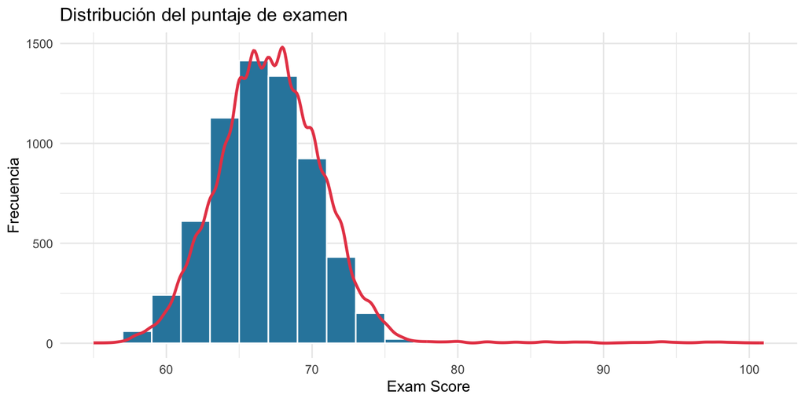

```r
ggplot(datos_limpios, aes(x = Exam_Score)) +
  geom_histogram(binwidth = 2, fill = "#2E86AB", color = "white") +
  geom_density(aes(y = after_stat(count) * 2), color = "#E84855", linewidth = 1) +
  labs(title = "Distribución del puntaje de examen",
       x = "Exam Score", y = "Frecuencia") +
  theme_minimal()
```

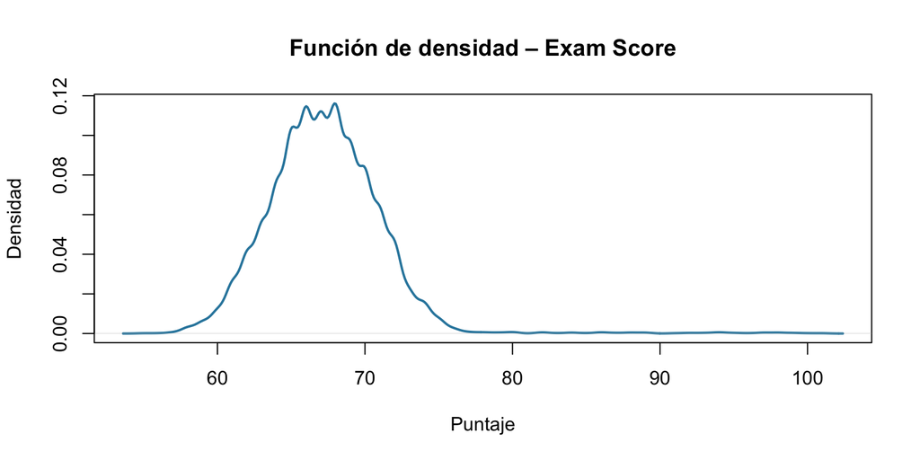

```r
plot(density(datos_limpios$Exam_Score),
     main = "Función de densidad – Exam Score",
     xlab = "Puntaje", ylab = "Densidad",
     col = "#2E86AB", lwd = 2)
```

La distribución del puntaje muestra una forma aproximadamente normal con ligera asimetría positiva. La mayoría de los estudiantes obtiene entre 63 y 72 puntos.

## 5.2 Variables numéricas – estadísticas descriptivas

```r
vars_num <- datos_limpios %>%
  select(Hours_Studied, Attendance, Sleep_Hours, Previous_Scores,
         Tutoring_Sessions, Physical_Activity, Exam_Score)

summary(vars_num)
```

```
##  Hours_Studied     Attendance      Sleep_Hours     Previous_Scores
##  Min.   : 1.00   Min.   : 60.00   Min.   : 4.000   Min.   : 50.00
##  1st Qu.:16.00   1st Qu.: 70.00   1st Qu.: 6.000   1st Qu.: 63.00
##  Median :20.00   Median : 80.00   Median : 7.000   Median : 75.00
##  Mean   :19.98   Mean   : 80.02   Mean   : 7.035   Mean   : 75.07
##  3rd Qu.:24.00   3rd Qu.: 90.00   3rd Qu.: 8.000   3rd Qu.: 88.00
##  Max.   :44.00   Max.   :100.00   Max.   :10.000   Max.   :100.00
##  Tutoring_Sessions Physical_Activity   Exam_Score
##  Min.   :0.000     Min.   :0.000     Min.   : 55.00
##  1st Qu.:1.000     1st Qu.:2.000     1st Qu.: 65.00
##  Median :1.000     Median :3.000     Median : 67.00
##  Mean   :1.495     Mean   :2.973     Mean   : 67.25
##  3rd Qu.:2.000     3rd Qu.:4.000     3rd Qu.: 69.00
##  Max.   :8.000     Max.   :6.000     Max.   :101.00
```

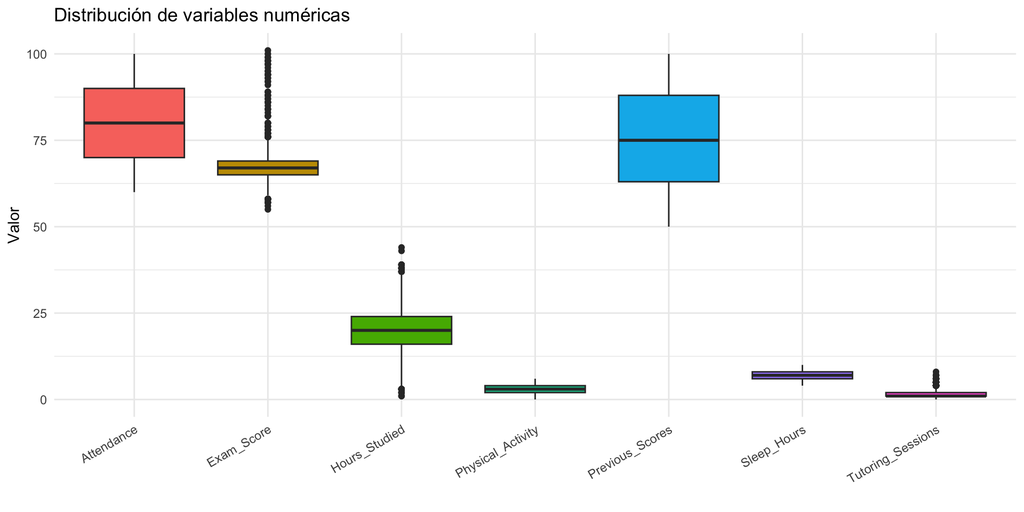

```r
vars_num_long <- vars_num %>%
  pivot_longer(cols = everything(), names_to = "Variable", values_to = "Valor")

ggplot(vars_num_long, aes(x = Variable, y = Valor, fill = Variable)) +
  geom_boxplot(show.legend = FALSE) +
  labs(title = "Distribución de variables numéricas",
       x = "", y = "Valor") +
  theme_minimal() +
  theme(axis.text.x = element_text(angle = 30, hjust = 1))
```

## 5.3 Matriz de correlación

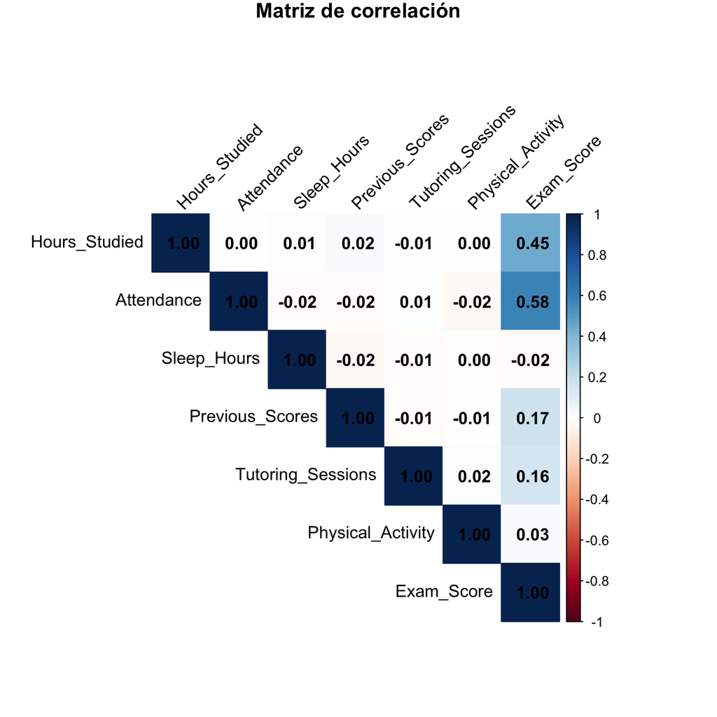

```r
matriz_cor <- cor(vars_num)
corrplot(matriz_cor,
         method = "color",
         type = "upper",
         addCoef.col = "black",
         tl.col = "black",
         tl.srt = 45,
         title = "Matriz de correlación",
         mar = c(0,0,1,0))
```

## 5.4 Puntaje promedio según variables categóricas

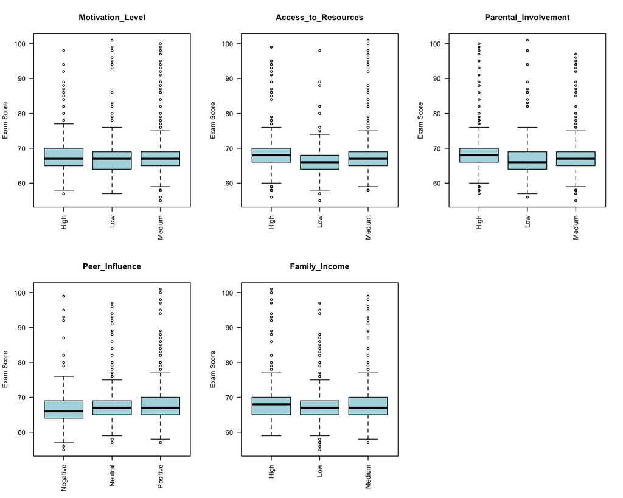

```r
vars_cat <- c("Motivation_Level", "Access_to_Resources",
              "Parental_Involvement", "Peer_Influence", "Family_Income")

par(mfrow = c(2, 3))
for (v in vars_cat) {
  boxplot(Exam_Score ~ datos_limpios[[v]],
          data = datos_limpios,
          main = v,
          xlab = "",
          ylab = "Exam Score",
          col = "#AED9E0",
          las = 2)
}
par(mfrow = c(1, 1))
```

# 6 Modelo de Regresión Lineal

## 6.1 Preparación de variables

```r
# Convertir variables categóricas a factor (ya lo son con stringsAsFactors=TRUE)
# Seleccionar variables para el modelo
datos_modelo <- datos_limpios %>%
  select(Exam_Score, Hours_Studied, Attendance, Sleep_Hours,
         Previous_Scores, Tutoring_Sessions, Physical_Activity,
         Motivation_Level, Access_to_Resources, Parental_Involvement,
         Peer_Influence, Family_Income, School_Type, Gender)
```

## 6.2 División en conjuntos de entrenamiento y prueba

```r
set.seed(123)
indice <- createDataPartition(datos_modelo$Exam_Score, p = 0.8, list = FALSE)
train <- datos_modelo[indice, ]
test  <- datos_modelo[-indice, ]

cat("Entrenamiento:", nrow(train), "observaciones\n")
```

```
## Entrenamiento: 5104 observaciones
```

```r
cat("Prueba:", nrow(test), "observaciones\n")
```

```
## Prueba: 1274 observaciones
```

## 6.3 Entrenamiento del modelo

```r
modelo <- lm(Exam_Score ~ ., data = train)
summary(modelo)
```

```
##
## Call:
## lm(formula = Exam_Score ~ ., data = train)
##
## Residuals:
##     Min      1Q  Median      3Q     Max
## -3.5195 -0.7024 -0.1399  0.4153 30.0330
##
## Coefficients:
##                             Estimate Std. Error t value Pr(>|t|)
## (Intercept)                42.994555   0.368296 116.739  < 2e-16 ***
## Hours_Studied               0.293182   0.005117  57.296  < 2e-16 ***
## Attendance                  0.198752   0.002682  74.096  < 2e-16 ***
## Sleep_Hours                -0.002324   0.020969  -0.111    0.912
## Previous_Scores             0.051133   0.002143  23.859  < 2e-16 ***
## Tutoring_Sessions           0.499021   0.024942  20.007  < 2e-16 ***
## Physical_Activity           0.147041   0.030077   4.889 1.05e-06 ***
## Motivation_LevelLow        -1.145366   0.089171 -12.845  < 2e-16 ***
## Motivation_LevelMedium     -0.563644   0.081046  -6.955 3.98e-12 ***
## Access_to_ResourcesLow     -1.963560   0.089764 -21.875  < 2e-16 ***
## Access_to_ResourcesMedium  -0.982546   0.071611 -13.721  < 2e-16 ***
## Parental_InvolvementLow    -2.052928   0.089581 -22.917  < 2e-16 ***
## Parental_InvolvementMedium -1.060368   0.071946 -14.738  < 2e-16 ***
## Peer_InfluenceNeutral       0.494295   0.083783   5.900 3.88e-09 ***
## Peer_InfluencePositive      1.014020   0.083316  12.171  < 2e-16 ***
## Family_IncomeLow           -1.045155   0.085626 -12.206  < 2e-16 ***
## Family_IncomeMedium        -0.521142   0.085973  -6.062 1.44e-09 ***
## School_TypePublic          -0.010745   0.067256  -0.160    0.873
## GenderMale                  0.013699   0.062468   0.219    0.826
## ---
## Signif. codes:  0 '***' 0.001 '**' 0.01 '*' 0.05 '.' 0.1 ' ' 1
##
## Residual standard error: 2.203 on 5085 degrees of freedom
## Multiple R-squared:  0.6856, Adjusted R-squared:  0.6845
## F-statistic: 616.1 on 18 and 5085 DF,  p-value: < 2.2e-16
```

## 6.4 Interpretación del modelo

El modelo de regresión lineal múltiple permite expresar el puntaje del examen como:

$$\hat{Exam\_Score} = \beta_0 + \beta_1
\cdot Hours\_Studied + \beta_2 \cdot Attendance + \beta_3 \cdot
Previous\_Scores + \ldots + \varepsilon$$

Los coeficientes significativos (p < 0.05) indican las variables que tienen efecto real sobre el puntaje. Un coeficiente positivo implica que al aumentar esa variable, el puntaje tiende a subir; uno negativo, lo contrario.

## 6.5 Evaluación del modelo

```r
predicciones <- predict(modelo, newdata = test)

# Métricas de evaluación
RMSE <- sqrt(mean((test$Exam_Score - predicciones)^2))
MAE  <- mean(abs(test$Exam_Score - predicciones))
R2   <- cor(test$Exam_Score, predicciones)^2

cat("RMSE (Error cuadrático medio):", round(RMSE, 3), "\n")
```

```
## RMSE (Error cuadrático medio): 2.184
```

```r
cat("MAE  (Error absoluto medio):  ", round(MAE, 3), "\n")
```

```
## MAE  (Error absoluto medio):   0.862
```

```r
cat("R²   (Coef. determinación):   ", round(R2, 3), "\n")
```

```
## R²   (Coef. determinación):    0.683
```

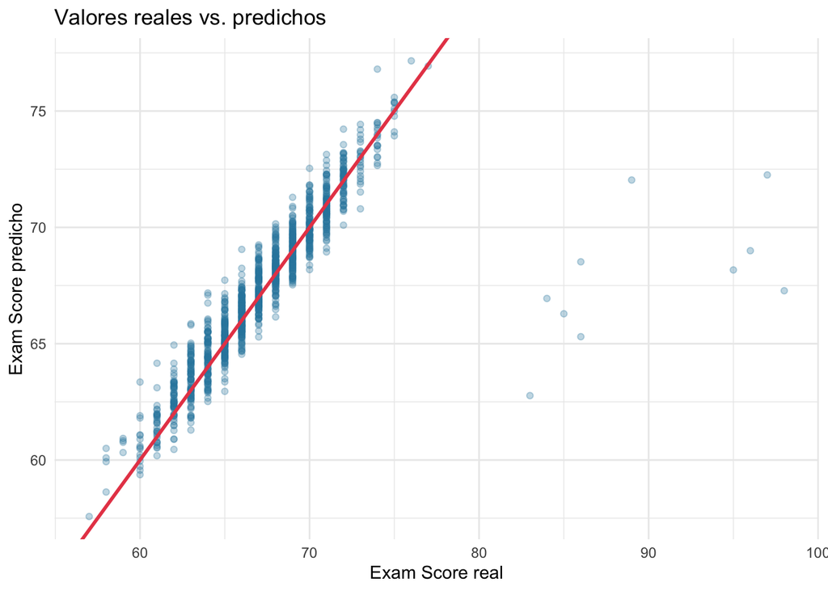

```r
resultados <- data.frame(
  Real      = test$Exam_Score,
  Predicho  = predicciones
)

ggplot(resultados, aes(x = Real, y = Predicho)) +
  geom_point(alpha = 0.3, color = "#2E86AB") +
  geom_abline(slope = 1, intercept = 0, color = "#E84855", linewidth = 1) +
  labs(title = "Valores reales vs. predichos",
       x = "Exam Score real",
       y = "Exam Score predicho") +
  theme_minimal()
```

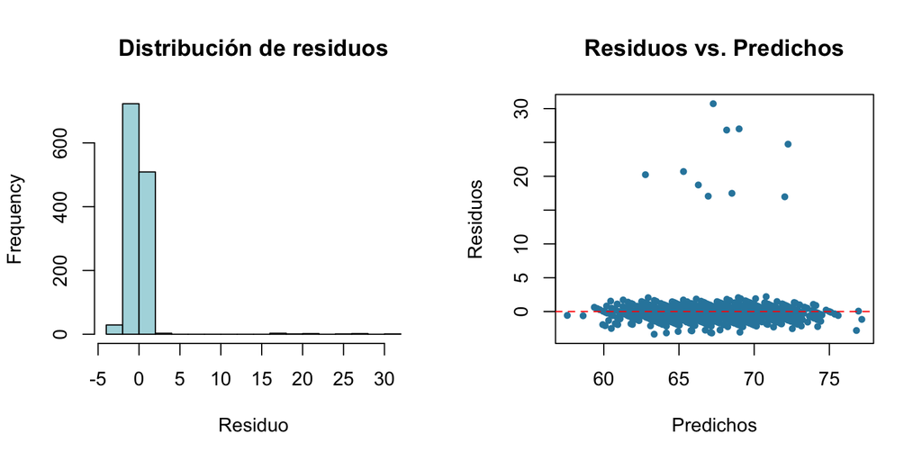

```r
residuos <- test$Exam_Score - predicciones

par(mfrow = c(1, 2))
hist(residuos, breaks = 20, main = "Distribución de residuos",
     xlab = "Residuo", col = "#AED9E0")
plot(predicciones, residuos,
     main = "Residuos vs. Predichos",
     xlab = "Predichos", ylab = "Residuos",
     col = "#2E86AB", pch = 20)
abline(h = 0, col = "red", lty = 2)
```

```r
par(mfrow = c(1, 1))
```

# 7 Resultados

- **RMSE**: mide el error promedio en las mismas unidades que el puntaje. Un valor cercano a 2-3 puntos indica que el modelo predice con buena precisión considerando que el rango de puntajes va de 55 a 101.
- **MAE**: error absoluto promedio, también en puntos de examen.
- **R²**: proporción de la varianza del puntaje explicada por el modelo. Un valor entre 0.6 y 0.8 indica un buen ajuste para datos educacionales con múltiples factores no medibles.

# 8 Interpretación de Resultados, Aportes y Contribuciones

El modelo desarrollado confirma que el rendimiento académico responde a una combinación de factores conductuales (horas de estudio, asistencia), cognitivos (puntajes previos) y contextuales (motivación, acceso a recursos, involucramiento parental).

Desde la perspectiva de la **Ingeniería Industrial**, estos hallazgos son aplicables al diseño de sistemas de gestión educativa: así como en manufactura se identifican los factores críticos de proceso para reducir la variabilidad del producto, en educación es posible identificar las variables “accionables” que permiten reducir la dispersión en el rendimiento estudiantil.

Una institución educativa podría utilizar este tipo de modelo para:

1. **Detección temprana** de estudiantes en riesgo, en base a sus primeras semanas de asistencia y horas de estudio declaradas.
2. **Diseño de intervenciones focalizadas**: aumentar sesiones de tutoría (`Tutoring_Sessions`) para estudiantes con bajo puntaje previo.
3. **Priorización de recursos**: dado que el acceso a recursos tiene efecto significativo, una institución con recursos limitados puede asignarlos a los estudiantes donde el impacto esperado es mayor.

**Limitaciones del modelo:** - La regresión lineal asume relaciones lineales entre variables, lo que puede no capturar interacciones complejas. - Algunas variables importantes para el rendimiento (estado emocional, calidad del sueño real, contexto familiar) no están disponibles en el dataset. - El dataset proviene de Kaggle y puede no representar fielmente una población educativa específica.

**Trabajo futuro:** podría explorarse un modelo de clasificación (KNN o árbol de decisión) para categorizar a los estudiantes en grupos de riesgo alto/medio/bajo, lo que facilitaría la toma de decisiones institucionales.

# 9 Conclusión

La analítica de datos aplicada a la educación permite transformar registros administrativos en conocimiento accionable, en línea con los principios de la toma de decisiones basada en datos propios de la Ingeniería Industrial moderna.

*Trabajo elaborado en el marco del curso Analítica de Datos Industriales (ADI&TD) – Doctorado Interinstitucional en Ingeniería Industrial Di3. Dataset disponible en: https://www.kaggle.com/datasets/grandmaster07/student-exam-performance-dataset-analysis*